# Discriminant Analysis with Various Examples

Data Mining

Description for Discriminant Analysis with Various Examples

Yeongeun Jeon , Jung In Seo  
2023-06-21

> Discriminant Analysis의 장점
- 고차원의 데이터셋을 관리가 훨씬 쉬운 저차원으로 축소하여 예측을 수행한다.
- 차원축소를 통해 얻은 판별점수는 다른 분류 예측 알고리듬의 예측 변수로 활용 가능하다.
- 정규성을 만족할 경우, 로지스틱 회귀분석보다 더 효과적이다.
  - 30% 정도 더 효과적인 성능을 발휘한다.
- 데이터셋의 크기가 작을 때 유용하게 적용할 수 있다.

> Discriminant Analysis의 단점
- 연속형 예측 변수만 가능하다.

# **예제 1**

- 판별분석을 수행하기 위해 사용되는 데이터는 이앤비플러스에서 출판한 책 **비즈니스 애널리틱스를 위한 데이터마이닝 (R Edition)**의 데이터 파일 중 “RidingMowers.csv”이다.
- 이 데이터는 승차식 잔디깎기 기계를 생산하는 제조업자가 도시 가구들을 대상으로 기계를 구입할 가구와 구입하지 않을 가구로 분류하고자 할 때, 시험 표본으로 승차식 잔디깎기 기계를 소유하고 있는 가구들 중 12가구와 그렇지 않은 가구들 중 12가구를 무작위로 선정하여 얻은 자료이다.
- 데이터에 포함되어 있는 변수는 다음과 같다.
  1. Income : 소득 수준
  2. Lot_Size : 정원 넓이
  3. Ownership : 잔디 깎기 기계 소유 여부
     - Owner : 소유
     - Nonowner : 소유 X

## **1. 데이터 불러오기**

```r
mowers <- read.csv("RidingMowers.csv")
head(mowers)
```

```
  Income Lot_Size Ownership
1   60.0     18.4     Owner
2   85.5     16.8     Owner
3   64.8     21.6     Owner
4   61.5     20.8     Owner
5   87.0     23.6     Owner
6  110.1     19.2     Owner
```

## **2. 데이터 전처리**

```r
pacman::p_load("dplyr")

## 예측변수 선택
mowers.X <- mowers %>%
  dplyr::select(1:2)

head(mowers.X)
```

```
  Income Lot_Size
1   60.0     18.4
2   85.5     16.8
3   64.8     21.6
4   61.5     20.8
5   87.0     23.6
6  110.1     19.2
```

```r
## 표준화
# mowers.X <- scale(mowers.X)
```

## **3. 공분산행렬의 동일성 검정**

```r
pacman::p_load("biotools")

mowers.boxM <- boxM(mowers.X,                     # Features
                    mowers$Ownership)             # Target
mowers.boxM
```

```
    Box's M-test for Homogeneity of Covariance Matrices

data:  mowers.X
Chi-Sq (approx.) = 0.99346, df = 3, p-value = 0.8028
```

`Result!` 가설 $H_0 : \boldsymbol{\Sigma}_{\text{Owner}}=\boldsymbol{\Sigma}_{\text{Nonowner}}$ vs $H_1 : \boldsymbol{\Sigma}_{\text{Owner}}\ne\boldsymbol{\Sigma}_{\text{Nonowner}}$에 대하여, 카이제곱 검정통계량 $\chi^2$ 값은 0.99346, $p$값은 0.8028이다. 이에 근거하여, 유의수준 5%에서 $p$값이 0.05보다 크기 때문에 귀무가설 $H_0$를 기각할 수 없다. 즉, 두 클래스의 공분산행렬이 동일하지 않다는 증거가 부족하다.

## **4. 선형판별분석(LDA)**

```r
# 함수 lda
pacman::p_load("MASS")

mowers.lda <- lda(Ownership ~ Income + Lot_Size,    # formula : 반응변수(클래스) ~ 예측변수
                  # prior = c(1/2, 1/2),            # 사전확률
                  data = mowers)
mowers.lda
```

```
Call:
lda(Ownership ~ Income + Lot_Size, data = mowers)

Prior probabilities of groups:
Nonowner    Owner
     0.5      0.5

Group means:
         Income Lot_Size
Nonowner 57.400 17.63333
Owner    79.475 20.26667

Coefficients of linear discriminants:
               LD1
Income   0.0484468
Lot_Size 0.3795228
```

`Result!` “Prior probabilities of groups”는 사전확률을 의미하며, 함수 `lda()`의 옵션 `prior`을 이용하여 직접 지정할 수 있다. 만약 옵션으로 따로 지정해주지 않는다면, 예제처럼 데이터에서 계산된 각 클래스의 비율이 사전확률로 지정된다. 즉, 데이터 “mowers”에서 잔디 깎기 기계 소유 집단과 그렇지 않은 집단의 비율은 각각 50%이다. “Groups means”는 판별변수들의 클래스별 평균을 의미한다. “Coefficients of linear discriminants”는 선형판별계수로 이 계수들을 이용하여 선형판별함수 $L(\boldsymbol{x})$를 표현하면 다음과 같다.

$$\begin{align}
0.0484(x_{\text{Income}}-\bar{x}_{\text{Income}})+0.3795(x_{\text{Lot_Size}}-\bar{x}_{\text{Lot_Size}}).
\end{align}$$
여기서, $\bar{x}_i$는 $i$번째 예측변수의 전체 평균을 의미한다.
선형판별계수들의 부호에 관심을 가지고 이를 해석해보면, Income과 Lot_Size가 클수록 $L(\boldsymbol{x})$가 커지며, 이는 잔디 깎기 기계를 소유할 확률이 커진다는 것을 의미한다. 반면, $L(\boldsymbol{x})$이 작을수록 잔디 깎기 기계를 소유하지 않을 확률이 커진다.

```r
# 새로운 개체에 대한 클래스 예측
pred.mowers <- predict(mowers.lda,                  # 함수 lda로부터 출력된 객체
                       mowers)                      # 새로운 데이터
pred.mowers
```

```
$class
 [1] Nonowner Owner    Owner    Owner    Owner    Owner    Owner
 [8] Owner    Owner    Owner    Owner    Owner    Owner    Nonowner
[15] Nonowner Nonowner Owner    Nonowner Nonowner Nonowner Nonowner
[22] Nonowner Nonowner Nonowner
Levels: Nonowner Owner

$posterior
     Nonowner       Owner
1  0.78203155 0.217968446
2  0.49449211 0.505507885
3  0.15236751 0.847632493
4  0.31924493 0.680755073
5  0.00402325 0.995976750
6  0.01246680 0.987533203
```

[output cut: 45 more lines]

```r
# 선형판별점수, 예측 확률, 예측 클래스
pf <- cbind(mowers, pred.mowers$x, pred.mowers$posterior, pred.mowers$class)
pf
```

```
   Income Lot_Size Ownership         LD1   Nonowner       Owner
1    60.0     18.4     Owner -0.61750748 0.78203155 0.217968446
2    85.5     16.8     Owner  0.01064948 0.49449211 0.505507885
3    64.8     21.6     Owner  0.82951029 0.15236751 0.847632493
4    61.5     20.8     Owner  0.36601756 0.31924493 0.680755073
5    87.0     23.6     Owner  2.66407504 0.00402325 0.995976750
6   110.1     19.2     Owner  2.11329570 0.01246680 0.987533203
7   108.0     17.6     Owner  1.40432086 0.05188913 0.948110866
8    82.8     22.4     Owner  2.00517105 0.01554353 0.984456467
9    69.0     20.0     Owner  0.42575032 0.29300716 0.706992840
10   93.0     20.8     Owner  1.89209190 0.01956031 0.980439689
11   51.0     22.0     Owner  0.31275353 0.34365520 0.656344803
12   81.0     20.0     Owner  1.00711197 0.11070233 0.889297671
13   75.0     19.6  Nonowner  0.56462200 0.23719290 0.762807097
14   52.8     20.8  Nonowner -0.05546964 0.52865847 0.471341530
```

[output cut: 35 more lines]

```r
# 오분류표
pacman::p_load("DescTools")

# 도수분포표
mowers.ctbl1 <- table(mowers$Ownership,             # 실제 클래스
                       pred.mowers$class)           # 예측 클래스
mowers.ctbl1
```

```
           Nonowner Owner
  Nonowner       10     2
  Owner           1    11
```

```r
Desc(mowers.ctbl1,                                  # 도수분포표
     digits = 4)
```

```
--------------------------------------------------------------------
mowers.ctbl1 (table)

Summary:
n: 24, rows: 2, columns: 2

Pearson's Chi-squared test (cont. adj):
  X-squared = 10.741, df = 1, p-value = 0.001048
Fisher's exact test p-value = 0.0006442
McNemar's chi-squared = 0, df = 1, p-value = 1

                    estimate   lwr.ci   upr.ci'

odds ratio           55.0000   4.3003 703.4323
rel. risk (col1)     10.0000   1.5054  66.4261
rel. risk (col2)      0.1818   0.0507   0.6517


Contingency Coeff.     0.601
Cramer's V             0.753
Kendall Tau-b          0.753


                   Nonowner     Owner       Sum

Nonowner   freq          10         2        12
           perc    41.6667%   8.3333%  50.0000%
           p.row   83.3333%  16.6667%         .
           p.col   90.9091%  15.3846%         .

Owner      freq           1        11        12
           perc     4.1667%  45.8333%  50.0000%
           p.row    8.3333%  91.6667%         .
           p.col    9.0909%  84.6154%         .

Sum        freq          11        13        24
           perc    45.8333%  54.1667% 100.0000%
           p.row          .         .         .
           p.col          .         .         .


----------
' 95% conf. level
```

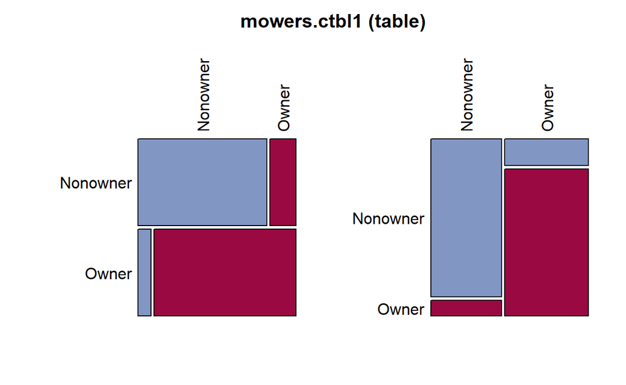

`Caution!` Package `"DescTools"`에서 제공하는 함수 `Desc()`를 이용하여 오분류표를 작성할 수 있다.  
`Result!` 원래 “Nonowner”에 속하는 12개의 개체 중 10개(10/12=83.33%)는 제대로 분류되었으나 2개(2/12=16.67%)는 “Owner”로 잘못 분류되었다. 또한, 원래 “Owner”에 속하는 12개의 개체 중 1개(1/12=8.33%)는 “Nonowner”로 잘못 분류되었으나 11개(11/12=91.67%)는 “Owner”에 제대로 분류되었다. 유도된 선형판별함수에 대한 오류율은 (2+1)/24=12.5%이며, 정확도는 (10+11)/24=87.5%이다.

## **5. 이차판별분석(QDA)**

```r
# 이차판별분석
pacman::p_load("MASS")

mowers.qda <- qda(Ownership ~ Income + Lot_Size,    # formula : 반응변수(클래스) ~ 예측변수
                  data = mowers)
mowers.qda
```

```
Call:
qda(Ownership ~ Income + Lot_Size, data = mowers)

Prior probabilities of groups:
Nonowner    Owner
     0.5      0.5

Group means:
         Income Lot_Size
Nonowner 57.400 17.63333
Owner    79.475 20.26667
```

`Caution!` 이차판별분석에서는 판별계수벡터를 출력하지 않는다.

```r
# 새로운 개체에 대한 클래스 예측
pred2.mowers <- predict(mowers.qda,               # 함수 qda로부터 출력된 객체
                        mowers)                   # 새로운 데이터
cbind(mowers, pred2.mowers$posterior, pred2.mowers$class)
```

```
   Income Lot_Size Ownership    Nonowner       Owner
1    60.0     18.4     Owner 0.817481728 0.182518272
2    85.5     16.8     Owner 0.424306433 0.575693567
3    64.8     21.6     Owner 0.196670872 0.803329128
4    61.5     20.8     Owner 0.362856648 0.637143352
5    87.0     23.6     Owner 0.008863376 0.991136624
6   110.1     19.2     Owner 0.002551633 0.997448367
7   108.0     17.6     Owner 0.009182382 0.990817618
8    82.8     22.4     Owner 0.025410871 0.974589129
9    69.0     20.0     Owner 0.342411556 0.657588444
10   93.0     20.8     Owner 0.016962533 0.983037467
11   51.0     22.0     Owner 0.320524407 0.679475593
12   81.0     20.0     Owner 0.119918671 0.880081329
13   75.0     19.6  Nonowner 0.267754450 0.732245550
14   52.8     20.8  Nonowner 0.518509465 0.481490535
```

[output cut: 35 more lines]

`Caution!` 이차판별분석에서 함수 `predict()`는 예측 클래스와 각 클래스에 대한 사후확률 예측값만 출력한다.

```r
# 오분류표
pacman::p_load("DescTools")

# 도수분포표
mowers.ctbl2 <- table(mowers$Ownership,           # 실제 클래스
                      pred2.mowers$class)         # 예측 클래스
mowers.ctbl2
```

```
           Nonowner Owner
  Nonowner       10     2
  Owner           1    11
```

```r
Desc(mowers.ctbl2,                                # 도수분포표
     digits = 4)
```

```
--------------------------------------------------------------------
mowers.ctbl2 (table)

Summary:
n: 24, rows: 2, columns: 2

Pearson's Chi-squared test (cont. adj):
  X-squared = 10.741, df = 1, p-value = 0.001048
Fisher's exact test p-value = 0.0006442
McNemar's chi-squared = 0, df = 1, p-value = 1

                    estimate   lwr.ci   upr.ci'

odds ratio           55.0000   4.3003 703.4323
rel. risk (col1)     10.0000   1.5054  66.4261
rel. risk (col2)      0.1818   0.0507   0.6517


Contingency Coeff.     0.601
Cramer's V             0.753
Kendall Tau-b          0.753


                   Nonowner     Owner       Sum

Nonowner   freq          10         2        12
           perc    41.6667%   8.3333%  50.0000%
           p.row   83.3333%  16.6667%         .
           p.col   90.9091%  15.3846%         .

Owner      freq           1        11        12
           perc     4.1667%  45.8333%  50.0000%
           p.row    8.3333%  91.6667%         .
           p.col    9.0909%  84.6154%         .

Sum        freq          11        13        24
           perc    45.8333%  54.1667% 100.0000%
           p.row          .         .         .
           p.col          .         .         .


----------
' 95% conf. level
```

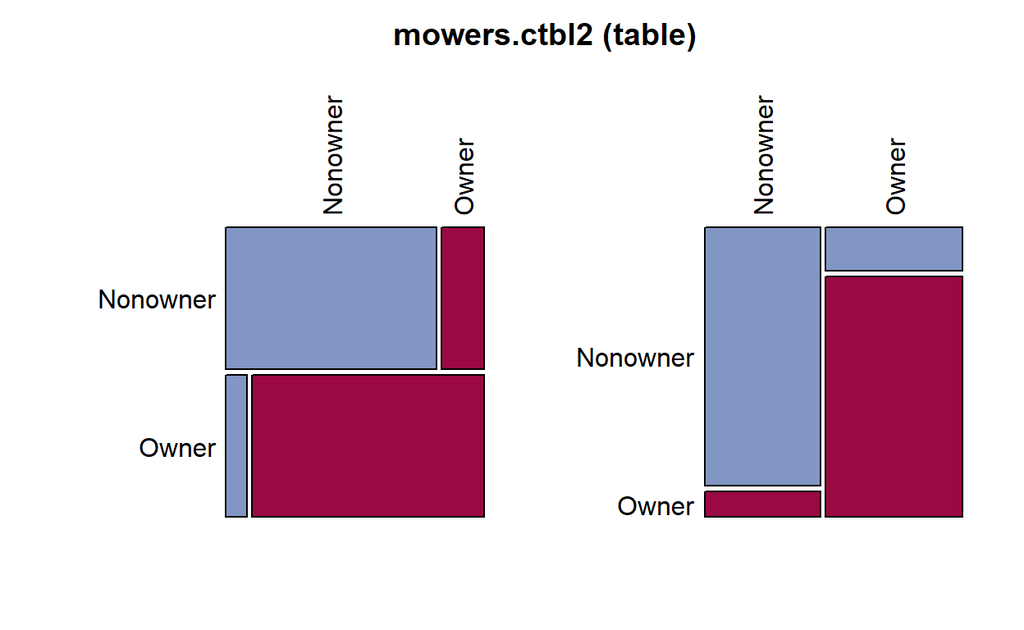

`Result!` 원래 “Nonowner”에 속하는 12개의 개체 중 10개(10/12=83.33%)는 제대로 분류되었으나 2개(2/12=16.67%)는 “Owner”로 잘못 분류되었다. 또한, 원래 “Owner”에 속하는 12개의 개체 중 1개(1/12=8.33%)는 “Nonowner”로 잘못 분류되었으나 11개(11/12=91.67%)는 “Owner”에 제대로 분류되었다. 유도된 이차판별함수에 대한 오류율은 (2+1)/24=12.5%이며, 정확도는 (10+11)/24=87.5%이다.

`Caution!` Package `"klaR"`에서 제공하는 함수 `partimat()`을 통해 판별분석의 분류 영역을 각 예측변수의 쌍에 대하여 표현할 수 있다.

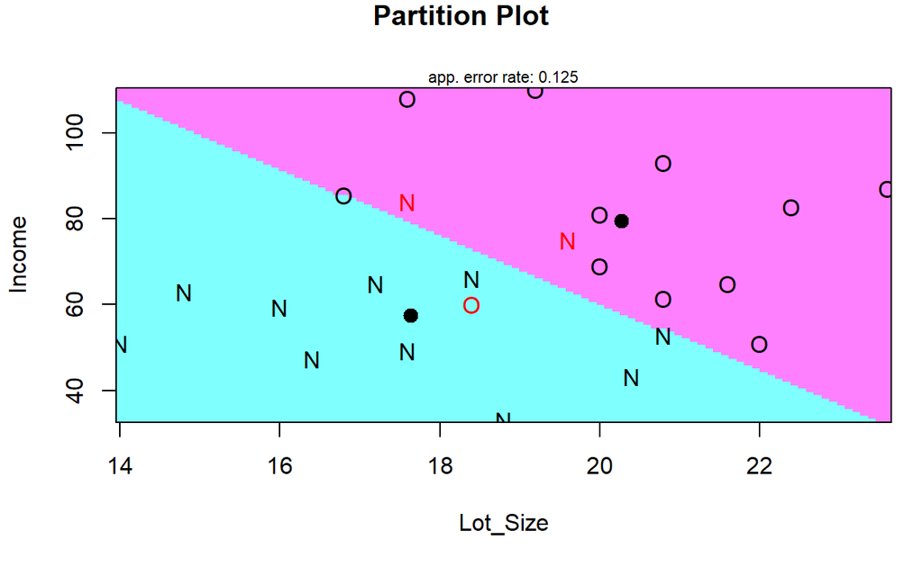

```r
# 그래프적 표현
pacman::p_load("klaR")

mowers$Ownership <- as.factor(mowers$Ownership)

# 선형판별함수
partimat(Ownership ~ Income + Lot_Size,
         data = mowers,
         method = "lda")
```

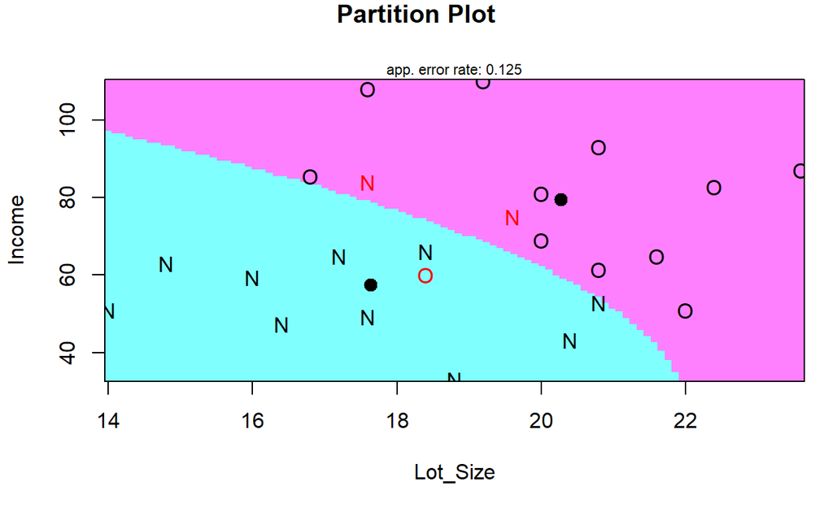

```r
# 이차판별함수
partimat(Ownership ~ Income + Lot_Size,
         data = mowers,
         method = "qda")
```

`Result!` 그래프를 통해 선형판별함수와 이차판별함수의 “선형”, “이차”라는 용어의 의미를 이해할 수 있다. 선형판별함수는 각 예측변수의 쌍에 대하여 “Nonowner” (N)와 “Owner” (O)는 선형(직선)으로 분류되었으며, 이차판별함수는 “Nonowner” (N)와 “Owner” (O)가 비선형으로 분류되었다. 또한, 각 집단에 대해 잘못 분류된 개체는 빨간색으로 표시되어 있다.

## **6. 오분류율 계산**

```r
# 1. 재대입에 의한 오분류율 계산
pacman::p_load("MASS")

mowers.lda <- lda(Ownership ~ Income + Lot_Size,    # formula : 반응변수(클래스) ~ 예측변수
                  # prior = c(1/2, 1/2),            # 사전확률
                  data = mowers)

## 예측
pred <- predict(mowers.lda,                         # 함수 lda로부터 출력된 객체
                mowers)                             # 판별함수를 유도하는 데 사용했던 데이터

## 오분류율 계산
## 함수 table()
ctbl <- table(mowers$Ownership,                     # 실제 클래스
              pred$class)                           # 예측 클래스
ctbl
```

```
           Nonowner Owner
  Nonowner       10     2
  Owner           1    11
```

```r
## 함수 Desc()
pacman::p_load("DescTools")

Desc(ctbl,                                          # 도수분포표
     digits = 4)
```

```
--------------------------------------------------------------------
ctbl (table)

Summary:
n: 24, rows: 2, columns: 2

Pearson's Chi-squared test (cont. adj):
  X-squared = 10.741, df = 1, p-value = 0.001048
Fisher's exact test p-value = 0.0006442
McNemar's chi-squared = 0, df = 1, p-value = 1

                    estimate   lwr.ci   upr.ci'

odds ratio           55.0000   4.3003 703.4323
rel. risk (col1)     10.0000   1.5054  66.4261
rel. risk (col2)      0.1818   0.0507   0.6517


Contingency Coeff.     0.601
Cramer's V             0.753
Kendall Tau-b          0.753


                   Nonowner     Owner       Sum

Nonowner   freq          10         2        12
           perc    41.6667%   8.3333%  50.0000%
           p.row   83.3333%  16.6667%         .
           p.col   90.9091%  15.3846%         .

Owner      freq           1        11        12
           perc     4.1667%  45.8333%  50.0000%
           p.row    8.3333%  91.6667%         .
           p.col    9.0909%  84.6154%         .

Sum        freq          11        13        24
           perc    45.8333%  54.1667% 100.0000%
           p.row          .         .         .
           p.col          .         .         .


----------
' 95% conf. level
```

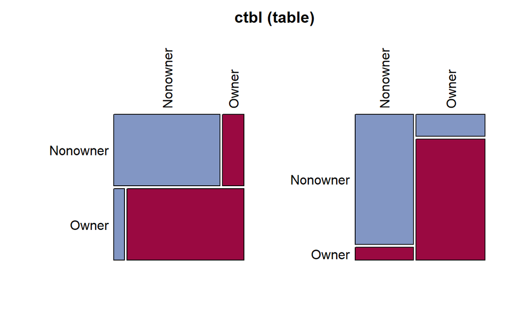

```r
## 함수 confusionMatrix()
pacman::p_load("caret")

confusionMatrix(pred$class,                          # 예측 클래스
                mowers$Ownership)                    # 실제 클래스
```

```
Confusion Matrix and Statistics

          Reference
Prediction Nonowner Owner
  Nonowner       10     1
  Owner           2    11

               Accuracy : 0.875
                 95% CI : (0.6764, 0.9734)
    No Information Rate : 0.5
    P-Value [Acc > NIR] : 0.0001386

                  Kappa : 0.75

 Mcnemar's Test P-Value : 1.0000000

            Sensitivity : 0.8333
            Specificity : 0.9167
         Pos Pred Value : 0.9091
         Neg Pred Value : 0.8462
             Prevalence : 0.5000
         Detection Rate : 0.4167
   Detection Prevalence : 0.4583
      Balanced Accuracy : 0.8750

       'Positive' Class : Nonowner
```

```r
# 2. 표본분할에 의한 오분류율 계산
## 표본 분할
pacman::p_load("caret")

set.seed(200)                                        # Seed 고정
ind <- createDataPartition(mowers$Ownership,         # 반응변수 (클래스)
                           p = .7,                   # 판별함수를 유도하는 데 사용되는 데이터 비율
                           list = F)                 # 출력 결과를 List로 반환할 것인지 여부

trd <- mowers[ind,]                                  # 판별함수를 유도하는 데 사용되는 데이터
ted <- mowers[-ind,]                                 # 오분류율 계산을 위해 사용되는 데이터
```

`Caution!` Package `"caret"`에서 제공하는 함수 `createDataPartition()`은 반응변수의 클래스별 비율을 원본 데이터와 같게 유지하면서 판별함수를 유도하는 데 사용할 데이터의 인덱스를 추출한다.

```r
pacman::p_load("MASS")

mowers.lda <- lda(Ownership ~ Income + Lot_Size,
                  data = trd)

## 예측
pred <- predict(mowers.lda,                          # 함수 lda로부터 출력된 객체
                ted)                                 # 새로운 데이터

## 오분류율 계산
## 함수 table()
ctbl <- table(ted$Ownership,                         # 실제 클래스
              pred$class)                            # 예측 클래스
ctbl
```

```
           Nonowner Owner
  Nonowner        2     1
  Owner           1     2
```

```r
## 함수 Desc()
pacman::p_load("DescTools")

Desc(ctbl,                                           # 도수분포표
     digits = 4)
```

```
--------------------------------------------------------------------
ctbl (table)

Summary:
n: 6, rows: 2, columns: 2

Pearson's Chi-squared test (cont. adj):
  X-squared = 0, df = 1, p-value = 1
Fisher's exact test p-value = 1
McNemar's chi-squared = 0, df = 1, p-value = 1

Warning message:
  Exp. counts < 5: Chi-squared approx. may be incorrect!!

                    estimate   lwr.ci   upr.ci'

odds ratio            4.0000   0.1342 119.2297
rel. risk (col1)      2.0000   0.3342  11.9693
rel. risk (col2)      0.5000   0.0835   2.9923


Contingency Coeff.     0.316
Cramer's V             0.333
Kendall Tau-b          0.333


                   Nonowner     Owner       Sum

Nonowner   freq           2         1         3
           perc    33.3333%  16.6667%  50.0000%
           p.row   66.6667%  33.3333%         .
           p.col   66.6667%  33.3333%         .

Owner      freq           1         2         3
           perc    16.6667%  33.3333%  50.0000%
           p.row   33.3333%  66.6667%         .
           p.col   33.3333%  66.6667%         .

Sum        freq           3         3         6
           perc    50.0000%  50.0000% 100.0000%
           p.row          .         .         .
           p.col          .         .         .


----------
' 95% conf. level
```

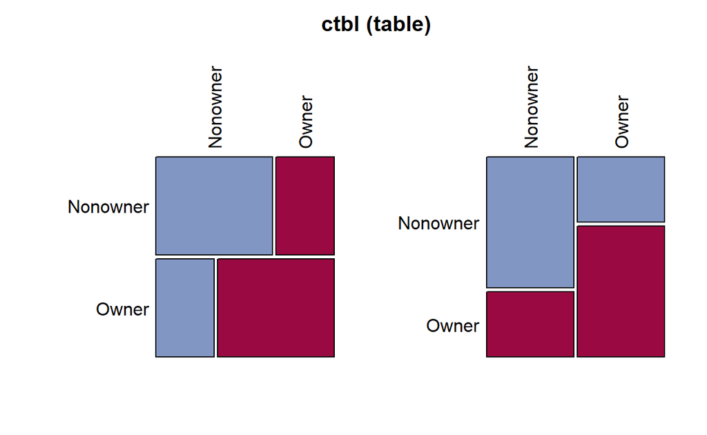

```r
## 함수 confusionMatrix()
pacman::p_load("caret")

confusionMatrix(pred$class,                          # 예측 클래스
                ted$Ownership)                       # 실제 클래스
```

```
Confusion Matrix and Statistics

          Reference
Prediction Nonowner Owner
  Nonowner        2     1
  Owner           1     2

               Accuracy : 0.6667
                 95% CI : (0.2228, 0.9567)
    No Information Rate : 0.5
    P-Value [Acc > NIR] : 0.3437

                  Kappa : 0.3333

 Mcnemar's Test P-Value : 1.0000

            Sensitivity : 0.6667
            Specificity : 0.6667
         Pos Pred Value : 0.6667
         Neg Pred Value : 0.6667
             Prevalence : 0.5000
         Detection Rate : 0.3333
   Detection Prevalence : 0.5000
      Balanced Accuracy : 0.6667

       'Positive' Class : Nonowner
```

```r
# 3. 교차타당성에 의한 오분류율 계산
pacman::p_load("MASS")

mowers.lda <- lda(Ownership ~ Income + Lot_Size,
                  data = mowers,
                  CV = TRUE)
```

`Caution!` 함수 `lda()`의 옵션 `CV = TRUE`을 지정하면 교차타당성에 의한 오분류율을 계산할 수 있다.

```r
## 오분류율 계산
## 함수 table()
ctbl <- table(mowers$Ownership,                     # 실제 클래스
              mowers.lda$class)                     # 예측 클래스
ctbl
```

```
           Nonowner Owner
  Nonowner        9     3
  Owner           2    10
```

```r
## 함수 Desc()
pacman::p_load("DescTools")

Desc(ctbl,                                           # 도수분포표
     digits = 4)
```

```
--------------------------------------------------------------------
ctbl (table)

Summary:
n: 24, rows: 2, columns: 2

Pearson's Chi-squared test (cont. adj):
  X-squared = 6.042, df = 1, p-value = 0.01397
Fisher's exact test p-value = 0.01228
McNemar's chi-squared = 0, df = 1, p-value = 1

                    estimate  lwr.ci  upr.ci'

odds ratio            15.000   2.024 111.174
rel. risk (col1)       4.500   1.218  16.622
rel. risk (col2)       0.300   0.109   0.825


Contingency Coeff.     0.505
Cramer's V             0.585
Kendall Tau-b          0.585


                   Nonowner     Owner       Sum

Nonowner   freq           9         3        12
           perc    37.5000%  12.5000%  50.0000%
           p.row   75.0000%  25.0000%         .
           p.col   81.8182%  23.0769%         .

Owner      freq           2        10        12
           perc     8.3333%  41.6667%  50.0000%
           p.row   16.6667%  83.3333%         .
           p.col   18.1818%  76.9231%         .

Sum        freq          11        13        24
           perc    45.8333%  54.1667% 100.0000%
           p.row          .         .         .
           p.col          .         .         .


----------
' 95% conf. level
```

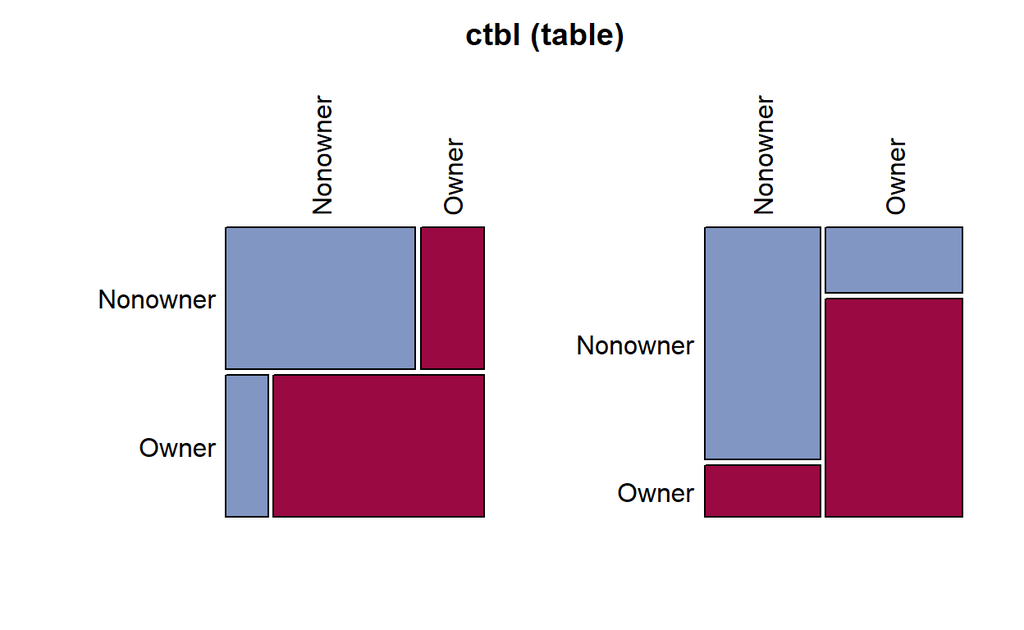

```r
## 함수 confusionMatrix()
pacman::p_load("caret")

confusionMatrix(mowers.lda$class,                    # 예측 클래스
                mowers$Ownership)                    # 실제 클래스
```

```
Confusion Matrix and Statistics

          Reference
Prediction Nonowner Owner
  Nonowner        9     2
  Owner           3    10

               Accuracy : 0.7917
                 95% CI : (0.5785, 0.9287)
    No Information Rate : 0.5
    P-Value [Acc > NIR] : 0.003305

                  Kappa : 0.5833

 Mcnemar's Test P-Value : 1.000000

            Sensitivity : 0.7500
            Specificity : 0.8333
         Pos Pred Value : 0.8182
         Neg Pred Value : 0.7692
             Prevalence : 0.5000
         Detection Rate : 0.3750
   Detection Prevalence : 0.4583
      Balanced Accuracy : 0.7917

       'Positive' Class : Nonowner
```

# **예제 2**

- 판별분석을 수행하기 위해 사용되는 데이터는 [자유아카데미](http://www.freeaca.com/new/library/BoardFileList.aspx?page=1&sword=%eb%8b%a4%eb%b3%80%eb%9f%89&stype=title&area=2)에서 출판한 책 **R을 활용한 다변량 자료분석 방법론**의 데이터 파일 중 “finance.csv”이다.
- 이 데이터는 금융거래의 거래인에 관한 자료로서, 변수들은 다음과 같다.
  1. $x_1$ : 총부채 대비 현금 유출입
  2. $x_2$ : 총자산 대비 순이익
  3. $x_3$ : 채무 대비 자산
  4. $x_4$ : 순매출 대비 자산
  5. $y$ : “1 = 파산 기업”, “2 = 건전 기업”
- 위와 같은 재무지표 데이터를 이용하여 거래인의 신용등급을 판별하고자 한다.

## **1. 데이터 불러오기**

```r
finance <- read.csv("finance.csv")
head(finance)
```

```
  ID     x1     x2    x3    x4 y
1  1 -0.448 -0.410 1.086 0.452 1
2  2 -0.563 -0.311 1.513 0.164 1
3  3  0.064  0.015 1.007 0.397 1
4  4 -0.072 -0.093 1.454 0.258 1
5  5 -0.100 -0.091 1.564 0.668 1
6  6 -0.142 -0.065 0.706 0.279 1
```

## **2. 데이터 전처리**

```r
pacman::p_load("dplyr")

## 예측변수 선택
finance.X <- finance %>%
  dplyr::select(2:5)

head(finance.X)
```

```
      x1     x2    x3    x4
1 -0.448 -0.410 1.086 0.452
2 -0.563 -0.311 1.513 0.164
3  0.064  0.015 1.007 0.397
4 -0.072 -0.093 1.454 0.258
5 -0.100 -0.091 1.564 0.668
6 -0.142 -0.065 0.706 0.279
```

```r
## 표준화
# finance.X <- scale(finance.X)
```

## **3. 공분산행렬의 동일성 검정**

```r
pacman::p_load("biotools")

finance.boxM <- boxM(finance.X,                   # Features
                     finance$y)                   # Target
finance.boxM
```

```
    Box's M-test for Homogeneity of Covariance Matrices

data:  finance.X
Chi-Sq (approx.) = 64.869, df = 10, p-value = 4.294e-10
```

`Result!` 가설 $H_0 : \boldsymbol{\Sigma}_1=\boldsymbol{\Sigma}_2$ vs $H_1 : \boldsymbol{\Sigma}_1\ne\boldsymbol{\Sigma}_2$에 대하여, 카이제곱 검정통계량 $\chi^2$ 값은 64.869, $p$값은 0에 가깝다. 이에 근거하여, 유의수준 5%에서 $p$값이 0.05보다 작기 때문에 귀무가설 $H_0$를 기각할 수 있다. 즉, 두 클래스의 공분산행렬은 동일하지 않다.

## **4. 선형판별분석(LDA)**

```r
# 함수 lda
pacman::p_load("MASS")

finance.lda <- lda(y ~ x1 + x2 + x3 + x4,           # formula : 반응변수(클래스) ~ 예측변수
                   # prior = c(1/2, 1/2),           # 사전확률
                   data = finance)
finance.lda
```

```
Call:
lda(y ~ x1 + x2 + x3 + x4, data = finance)

Prior probabilities of groups:
        1         2
0.4565217 0.5434783

Group means:
           x1          x2       x3        x4
1 -0.07319048 -0.08180952 1.367048 0.4378571
2  0.23492000  0.05472000 2.580400 0.4281200

Coefficients of linear discriminants:
          LD1
x1  1.0023665
x2  3.9998578
x3  0.8450508
x4 -1.0153181
```

`Result!` “Prior probabilities of groups”는 사전확률을 의미하며, 함수 `lda()`의 옵션 `prior`을 이용하여 직접 지정할 수 있다. 만약 옵션으로 따로 지정해주지 않는다면, 예제처럼 데이터에서 계산된 각 클래스의 비율이 사전확률로 지정된다. 즉, 데이터 “finance”에서 파산 기업($y=1$)의 비율은 46%, 건전 기업($y=2$)의 비율은 54%이다. “Groups means”는 판별변수들의 클래스별 평균을 의미한다. 예를 들어, 변수 $x_4$(순매출 대비 자산)은 두 클래스의 평균이 0.438과 0.428로서 큰 차이가 없으므로, 이 변수는 판별에 기여하는 정도가 작을 것임을 짐작할 수 있다. “Coefficients of linear discriminants”는 선형판별계수로 이 계수들을 이용하여 선형판별함수 $L(\boldsymbol{x})$를 표현하면 다음과 같다.

$$\begin{align}
1.002(x_1-\bar{x}_1)+3.999(x_2-\bar{x}_2)+0.845(x_3-\bar{x}_3)-1.015(x_4-\bar{x}_4).
\end{align}$$
여기서, $\bar{x}_i$는 $i$번째 예측변수의 전체 평균을 의미한다.
선형판별계수들의 부호에 관심을 가지고 이를 해석해보면, $x_1$(총부채 대비 현금 유출입), $x_2$(총자산 대비 순이익), $x_3$(채무 대비 자산)이 클수록 $L(\boldsymbol{x})$ 값이 커지므로 파산 기업($y=1$)에 비해 건전 기업($y=2$)에 속할 확률의 추정치가 커지며, 반면에 $x_4$(순매출 대비 자산)이 클수록 $L(\boldsymbol{x})$ 값이 작아지므로 건전 기업($y=2$)에 속할 확률의 추정치가 작아진다.

```r
# 새로운 개체에 대한 클래스 예측
pred.finance <- predict(finance.lda,                # 함수 lda로부터 출력된 객체
                        finance)                    # 새로운 데이터
pred.finance
```

```
$class
 [1] 1 1 1 1 1 1 1 1 1 1 1 1 1 1 2 2 1 1 1 2 1 2 2 2 2 2 2 2 2 2 2 2 2
[34] 1 2 2 2 2 2 2 2 2 2 2 2 2
Levels: 1 2

$posterior
              1           2
1  0.9949306255 0.005069374
2  0.9710865699 0.028913430
3  0.7534057857 0.246594214
4  0.7703536176 0.229646382
5  0.8652242888 0.134775711
6  0.9142224102 0.085777590
7  0.7275761568 0.272423843
8  0.7900065070 0.209993493
```

[output cut: 87 more lines]

```r
# 선형판별점수, 예측 확률, 예측 클래스
pf <- cbind(finance, pred.finance$x, pred.finance$posterior, pred.finance$class)
pf
```

```
   ID     x1     x2    x3    x4 y          LD1            1
1   1 -0.448 -0.410 1.086 0.452 1 -2.967536513 0.9949306255
2   2 -0.563 -0.311 1.513 0.164 1 -2.033574427 0.9710865699
3   3  0.064  0.015 1.007 0.397 1 -0.765301792 0.7534057857
4   4 -0.072 -0.093 1.454 0.258 1 -0.814741367 0.7703536176
5   5 -0.100 -0.091 1.564 0.668 1 -1.158132769 0.8652242888
6   6 -0.142 -0.065 0.706 0.279 1 -1.426330659 0.9142224102
7   7  0.035  0.014 1.504 0.708 1 -0.694143990 0.7275761568
8   8 -0.065 -0.056 1.373 0.403 1 -0.875400305 0.7900065070
9   9 -0.072 -0.007 1.372 0.336 1 -0.619242570 0.6986301491
10 10 -0.135 -0.143 1.419 0.434 1 -1.286156120 0.8910355393
11 11 -0.229 -0.296 0.331 0.182 1 -2.655911886 0.9909008401
12 12  0.073  0.020 1.312 0.249 1 -0.328273634 0.5721926558
13 13  0.010  0.001 2.149 0.696 1 -0.213959740 0.5186738620
14 14 -0.227 -0.231 1.191 0.660 1 -2.152494806 0.9767718689
```

[output cut: 79 more lines]

```r
# 오분류표
pacman::p_load("DescTools")

# 도수분포표
finance.ctbl1 <- table(finance$y,                   # 실제 클래스
                       pred.finance$class)          # 예측 클래스
finance.ctbl1
```

```
     1  2
  1 18  3
  2  1 24
```

```r
Desc(finance.ctbl1,                                 # 도수분포표
     digits = 4)
```

```
--------------------------------------------------------------------
finance.ctbl1 (table)

Summary:
n: 46, rows: 2, columns: 2

Pearson's Chi-squared test (cont. adj):
  X-squared = 28.154, df = 1, p-value = 1.121e-07
Fisher's exact test p-value = 8.054e-09
McNemar's chi-squared = 0.25, df = 1, p-value = 0.6171

                    estimate   lwr.ci   upr.ci'

odds ratio           144.000   13.813 1501.237
rel. risk (col1)      21.429    3.116  147.380
rel. risk (col2)       0.149    0.052    0.426


Contingency Coeff.     0.637
Cramer's V             0.827
Kendall Tau-b          0.827


                    1         2       Sum

1     freq         18         3        21
      perc   39.1304%   6.5217%  45.6522%
      p.row  85.7143%  14.2857%         .
      p.col  94.7368%  11.1111%         .

2     freq          1        24        25
      perc    2.1739%  52.1739%  54.3478%
      p.row   4.0000%  96.0000%         .
      p.col   5.2632%  88.8889%         .

Sum   freq         19        27        46
      perc   41.3043%  58.6957% 100.0000%
      p.row         .         .         .
      p.col         .         .         .


----------
' 95% conf. level
```

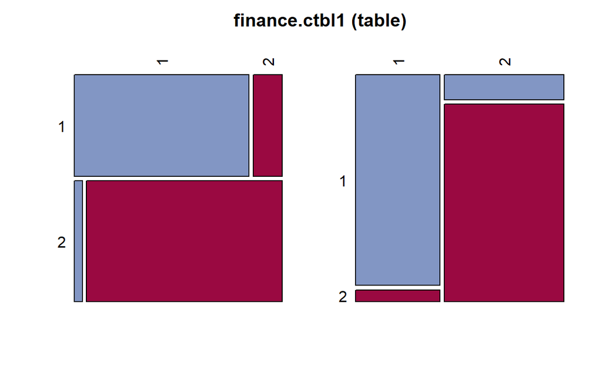

`Result!` 원래 집단 1에 속하는 21개의 개체 중 18개(18/21=85.7%)는 집단 1에 제대로 분류되었으나 3개(3/21=14.3%)는 집단 2로 잘못 분류되었다. 또한, 원래 집단 2에 속하는 25개의 개체 중 1개(1/25=4%)는 집단 1로 잘못 분류되었으나 24개(24/25=96%)는 집단 2에 제대로 분류되었다. 유도된 선형판별함수에 대한 오류율은 (3+1)/46=8.7%이며, 정확도는 (18+24)/46=91.3%이다.

## **5. 이차판별분석(QDA)**

```r
# 이차판별분석
pacman::p_load("MASS")

finance.qda <- qda(y ~ x1 + x2 + x3 + x4,           # formula : 반응변수(클래스) ~ 예측변수
                   data = finance)
finance.qda
```

```
Call:
qda(y ~ x1 + x2 + x3 + x4, data = finance)

Prior probabilities of groups:
        1         2
0.4565217 0.5434783

Group means:
           x1          x2       x3        x4
1 -0.07319048 -0.08180952 1.367048 0.4378571
2  0.23492000  0.05472000 2.580400 0.4281200
```

`Caution!` 이차판별분석에서는 판별계수벡터를 출력하지 않는다.

```r
# 새로운 개체에 대한 클래스 예측
pred2.finance <- predict(finance.qda,               # 함수 qda로부터 출력된 객체
                         finance)                   # 새로운 데이터
cbind(finance, pred2.finance$posterior, pred2.finance$class)
```

```
   ID     x1     x2    x3    x4 y            1            2
1   1 -0.448 -0.410 1.086 0.452 1 1.000000e+00 3.116818e-39
2   2 -0.563 -0.311 1.513 0.164 1 1.000000e+00 1.111932e-14
3   3  0.064  0.015 1.007 0.397 1 5.421135e-01 4.578865e-01
4   4 -0.072 -0.093 1.454 0.258 1 9.983000e-01 1.699964e-03
5   5 -0.100 -0.091 1.564 0.668 1 9.999242e-01 7.579056e-05
6   6 -0.142 -0.065 0.706 0.279 1 8.842837e-01 1.157163e-01
7   7  0.035  0.014 1.504 0.708 1 8.582123e-01 1.417877e-01
8   8 -0.065 -0.056 1.373 0.403 1 9.739957e-01 2.600431e-02
9   9 -0.072 -0.007 1.372 0.336 1 5.907891e-01 4.092109e-01
10 10 -0.135 -0.143 1.419 0.434 1 9.999995e-01 4.807386e-07
11 11 -0.229 -0.296 0.331 0.182 1 1.000000e+00 3.046234e-22
12 12  0.073  0.020 1.312 0.249 1 6.209643e-01 3.790357e-01
13 13  0.010  0.001 2.149 0.696 1 5.581252e-01 4.418748e-01
14 14 -0.227 -0.231 1.191 0.660 1 1.000000e+00 3.388701e-17
```

[output cut: 79 more lines]

`Caution!` 이차판별분석에서 함수 `predict()`는 예측 클래스와 각 클래스에 대한 사후확률 예측값만 출력한다.

```r
# 오분류표
pacman::p_load("DescTools")

# 도수분포표
finance.ctbl2 <- table(finance$y,                   # 실제 클래스
                       pred2.finance$class)         # 예측 클래스
finance.ctbl2
```

```
     1  2
  1 19  2
  2  1 24
```

```r
Desc(finance.ctbl2,                                 # 도수분포표
     digits = 4)
```

```
--------------------------------------------------------------------
finance.ctbl2 (table)

Summary:
n: 46, rows: 2, columns: 2

Pearson's Chi-squared test (cont. adj):
  X-squared = 31.3, df = 1, p-value = 2.21e-08
Fisher's exact test p-value = 9.399e-10
McNemar's chi-squared = 0, df = 1, p-value = 1

                    estimate   lwr.ci   upr.ci'

odds ratio          2.28e+02 1.92e+01 2.71e+03
rel. risk (col1)    2.26e+01 3.30e+00 1.55e+02
rel. risk (col2)    9.92e-02 2.65e-02 3.72e-01


Contingency Coeff.     0.656
Cramer's V             0.869
Kendall Tau-b          0.869


                    1         2       Sum

1     freq         19         2        21
      perc   41.3043%   4.3478%  45.6522%
      p.row  90.4762%   9.5238%         .
      p.col  95.0000%   7.6923%         .

2     freq          1        24        25
      perc    2.1739%  52.1739%  54.3478%
      p.row   4.0000%  96.0000%         .
      p.col   5.0000%  92.3077%         .

Sum   freq         20        26        46
      perc   43.4783%  56.5217% 100.0000%
      p.row         .         .         .
      p.col         .         .         .


----------
' 95% conf. level
```

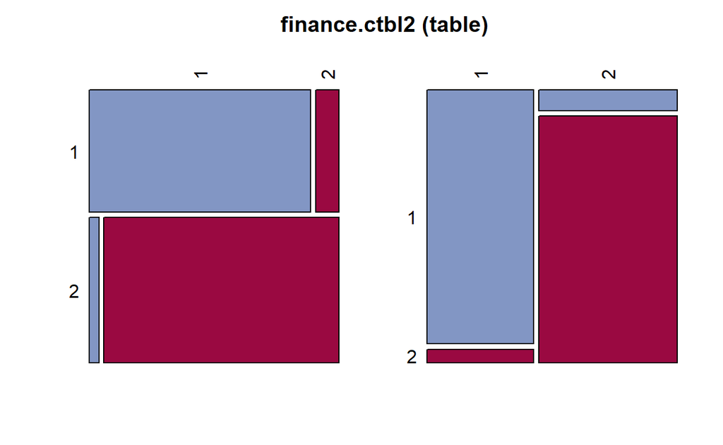

`Caution!` Package `"klaR"`에서 제공하는 함수 `partimat()`을 통해 판별분석의 분류 영역을 각 예측변수의 쌍에 대하여 표현할 수 있다.

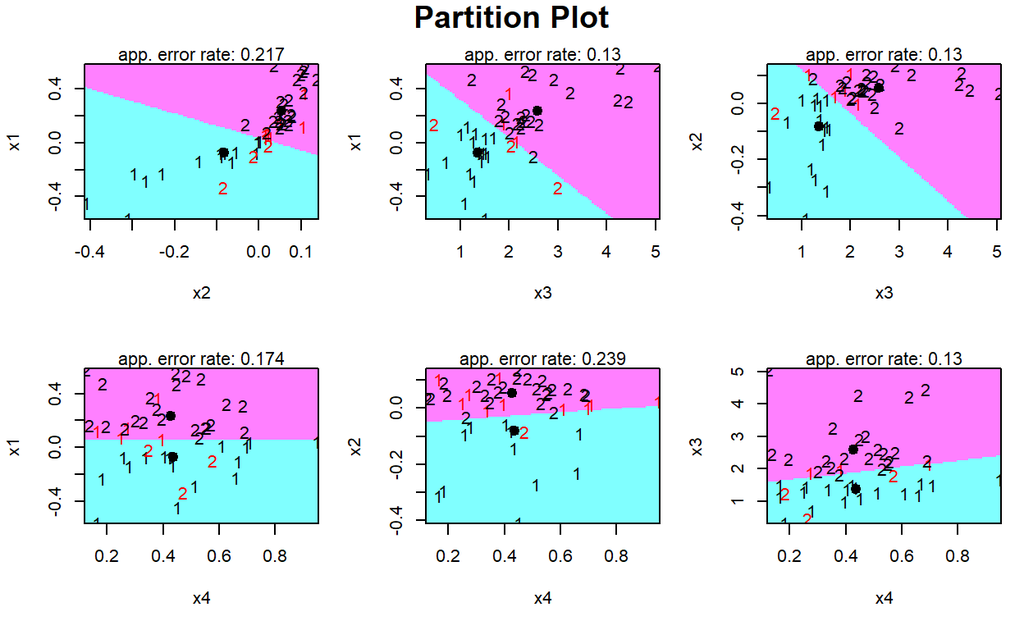

```r
# 그래프적 표현
pacman::p_load("klaR")

finance$y <- as.factor(finance$y)

# 선형판별함수
partimat(y ~ x1 + x2 + x3 + x4,
         data = finance,
         method = "lda")
```

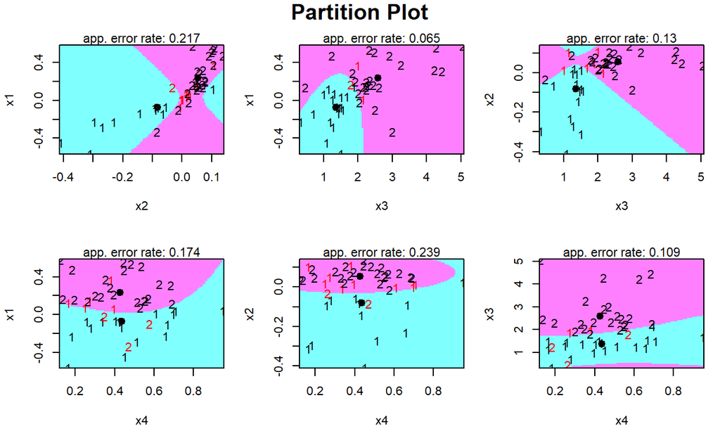

```r
# 이차판별함수
partimat(y ~ x1 + x2 + x3 + x4,
         data = finance,
         method = "qda")
```

## **6. 오분류율 계산**

```r
# 1. 재대입에 의한 오분류율 계산
pacman::p_load("MASS")

finance.lda <- lda(y ~ x1 + x2 + x3 + x4,           # formula : 반응변수(클래스) ~ 예측변수
                   # prior = c(1/2, 1/2),           # 사전확률
                   data = finance)

## 예측
pred <- predict(finance.lda,                        # 함수 lda로부터 출력된 객체
                finance)                            # 판별함수를 유도하는 데 사용했던 데이터

## 오분류율 계산
## 함수 table()
ctbl <- table(finance$y,                            # 실제 클래스
              pred$class)                           # 예측 클래스
ctbl
```

```
     1  2
  1 18  3
  2  1 24
```

```r
## 함수 Desc()
pacman::p_load("DescTools")

Desc(ctbl,                                          # 도수분포표
     digits = 4)
```

```
--------------------------------------------------------------------
ctbl (table)

Summary:
n: 46, rows: 2, columns: 2

Pearson's Chi-squared test (cont. adj):
  X-squared = 28.154, df = 1, p-value = 1.121e-07
Fisher's exact test p-value = 8.054e-09
McNemar's chi-squared = 0.25, df = 1, p-value = 0.6171

                    estimate   lwr.ci   upr.ci'

odds ratio           144.000   13.813 1501.237
rel. risk (col1)      21.429    3.116  147.380
rel. risk (col2)       0.149    0.052    0.426


Contingency Coeff.     0.637
Cramer's V             0.827
Kendall Tau-b          0.827


                    1         2       Sum

1     freq         18         3        21
      perc   39.1304%   6.5217%  45.6522%
      p.row  85.7143%  14.2857%         .
      p.col  94.7368%  11.1111%         .

2     freq          1        24        25
      perc    2.1739%  52.1739%  54.3478%
      p.row   4.0000%  96.0000%         .
      p.col   5.2632%  88.8889%         .

Sum   freq         19        27        46
      perc   41.3043%  58.6957% 100.0000%
      p.row         .         .         .
      p.col         .         .         .


----------
' 95% conf. level
```

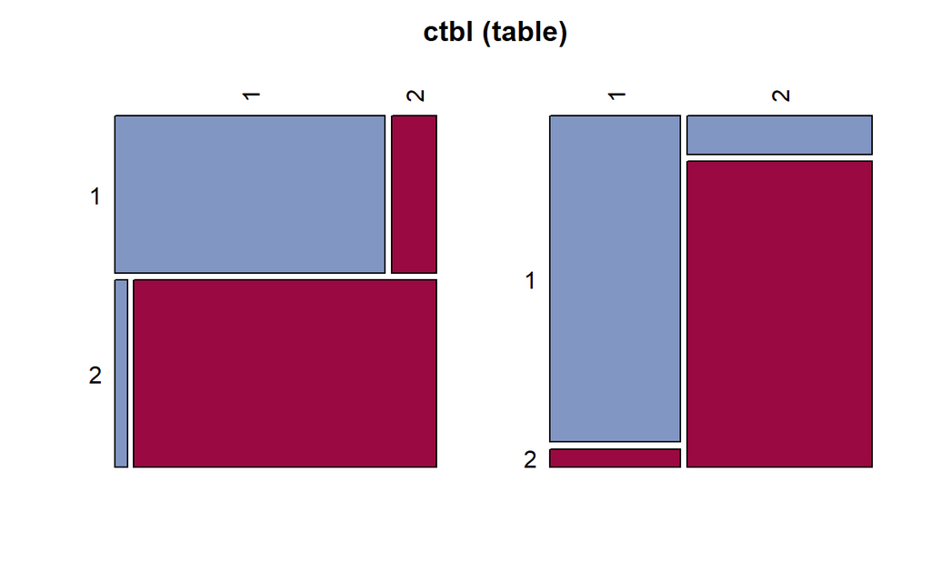

```r
## 함수 confusionMatrix()
pacman::p_load("caret")

confusionMatrix(pred$class,                          # 예측 클래스
                finance$y)                           # 실제 클래스
```

```
Confusion Matrix and Statistics

          Reference
Prediction  1  2
         1 18  1
         2  3 24

               Accuracy : 0.913
                 95% CI : (0.7921, 0.9758)
    No Information Rate : 0.5435
    P-Value [Acc > NIR] : 5.991e-08

                  Kappa : 0.8234

 Mcnemar's Test P-Value : 0.6171

            Sensitivity : 0.8571
            Specificity : 0.9600
         Pos Pred Value : 0.9474
         Neg Pred Value : 0.8889
             Prevalence : 0.4565
         Detection Rate : 0.3913
   Detection Prevalence : 0.4130
      Balanced Accuracy : 0.9086

       'Positive' Class : 1
```

```r
# 2. 표본분할에 의한 오분류율 계산
## 표본 분할
pacman::p_load("caret")

set.seed(200)                                        # Seed 고정
ind <- createDataPartition(finance$y,                # 반응변수 (클래스)
                           p = .7,                   # 판별함수를 유도하는 데 사용되는 데이터 비율
                           list = F)                 # 출력 결과를 List로 반환할 것인지 여부

trd <- finance[ind,]                                 # 판별함수를 유도하는 데 사용되는 데이터
ted <- finance[-ind,]                                # 오분류율 계산을 위해 사용되는 데이터
```

```r
pacman::p_load("MASS")

finance.lda <- lda(y ~ x1 + x2 + x3 + x4,
                   data = trd)

## 예측
pred <- predict(finance.lda,                         # 함수 lda로부터 출력된 객체
                ted)                                 # 새로운 데이터

## 오분류율 계산
## 함수 table()
ctbl <- table(ted$y,                                 # 실제 클래스
              pred$class)                            # 예측 클래스
ctbl
```

```
    1 2
  1 5 1
  2 0 7
```

```r
## 함수 Desc()
pacman::p_load("DescTools")

Desc(ctbl,                                           # 도수분포표
     digits = 4)
```

```
--------------------------------------------------------------------
ctbl (table)

Summary:
n: 13, rows: 2, columns: 2

Pearson's Chi-squared test (cont. adj):
  X-squared = 6.2853, df = 1, p-value = 0.01217
Fisher's exact test p-value = 0.004662
McNemar's chi-squared = 0, df = 1, p-value = 1

Warning message:
  Exp. counts < 5: Chi-squared approx. may be incorrect!!

                    estimate   lwr.ci   upr.ci'

odds ratio          5.50e+01 1.86e+00 1.62e+03
rel. risk (col1)         Inf      NaN      Inf
rel. risk (col2)    1.67e-01 2.78e-02 9.97e-01


Contingency Coeff.     0.649
Cramer's V             0.854
Kendall Tau-b          0.854


                    1         2       Sum

1     freq          5         1         6
      perc   38.4615%   7.6923%  46.1538%
      p.row  83.3333%  16.6667%         .
      p.col 100.0000%  12.5000%         .

2     freq          0         7         7
      perc    0.0000%  53.8462%  53.8462%
      p.row   0.0000% 100.0000%         .
      p.col   0.0000%  87.5000%         .

Sum   freq          5         8        13
      perc   38.4615%  61.5385% 100.0000%
      p.row         .         .         .
      p.col         .         .         .


----------
' 95% conf. level
```

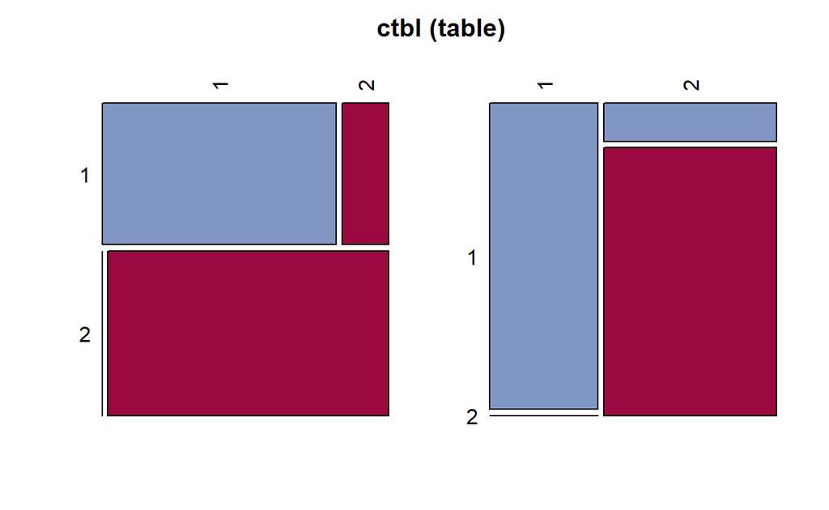

```r
## 함수 confusionMatrix()
pacman::p_load("caret")

confusionMatrix(pred$class,                          # 예측 클래스
                ted$y)                               # 실제 클래스
```

```
Confusion Matrix and Statistics

          Reference
Prediction 1 2
         1 5 0
         2 1 7

               Accuracy : 0.9231
                 95% CI : (0.6397, 0.9981)
    No Information Rate : 0.5385
    P-Value [Acc > NIR] : 0.003884

                  Kappa : 0.8434

 Mcnemar's Test P-Value : 1.000000

            Sensitivity : 0.8333
            Specificity : 1.0000
         Pos Pred Value : 1.0000
         Neg Pred Value : 0.8750
             Prevalence : 0.4615
         Detection Rate : 0.3846
   Detection Prevalence : 0.3846
      Balanced Accuracy : 0.9167

       'Positive' Class : 1
```

```r
# 3. 교차타당성에 의한 오분류율 계산
pacman::p_load("MASS")

finance.lda <- lda(y ~ x1 + x2 + x3 + x4,
                   data = finance,
                   CV = TRUE)
```

```r
## 오분류율 계산
## 함수 table()
ctbl <- table(finance$y,                             # 실제 클래스
              finance.lda$class)                     # 예측 클래스
ctbl
```

```
     1  2
  1 17  4
  2  2 23
```

```r
## 함수 Desc()
pacman::p_load("DescTools")

Desc(ctbl,                                           # 도수분포표
     digits = 4)
```

```
--------------------------------------------------------------------
ctbl (table)

Summary:
n: 46, rows: 2, columns: 2

Pearson's Chi-squared test (cont. adj):
  X-squared = 22.135, df = 1, p-value = 2.541e-06
Fisher's exact test p-value = 4.829e-07
McNemar's chi-squared = 0.16667, df = 1, p-value = 0.6831

                    estimate   lwr.ci   upr.ci'

odds ratio           48.8750   8.0031 298.4817
rel. risk (col1)     10.1190   2.6353  38.8545
rel. risk (col2)      0.2070   0.0851   0.5038


Contingency Coeff.     0.594
Cramer's V             0.738
Kendall Tau-b          0.738


                    1         2       Sum

1     freq         17         4        21
      perc   36.9565%   8.6957%  45.6522%
      p.row  80.9524%  19.0476%         .
      p.col  89.4737%  14.8148%         .

2     freq          2        23        25
      perc    4.3478%  50.0000%  54.3478%
      p.row   8.0000%  92.0000%         .
      p.col  10.5263%  85.1852%         .

Sum   freq         19        27        46
      perc   41.3043%  58.6957% 100.0000%
      p.row         .         .         .
      p.col         .         .         .


----------
' 95% conf. level
```

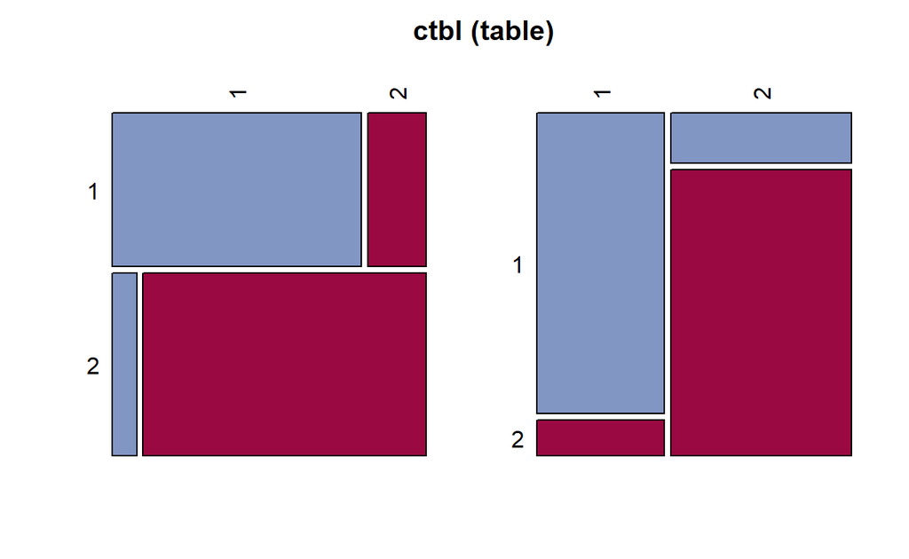

```r
## 함수 confusionMatrix()
pacman::p_load("caret")

confusionMatrix(finance.lda$class,                   # 예측 클래스
                finance$y)                           # 실제 클래스
```

```
Confusion Matrix and Statistics

          Reference
Prediction  1  2
         1 17  2
         2  4 23

               Accuracy : 0.8696
                 95% CI : (0.7374, 0.9506)
    No Information Rate : 0.5435
    P-Value [Acc > NIR] : 2.603e-06

                  Kappa : 0.7351

 Mcnemar's Test P-Value : 0.6831

            Sensitivity : 0.8095
            Specificity : 0.9200
         Pos Pred Value : 0.8947
         Neg Pred Value : 0.8519
             Prevalence : 0.4565
         Detection Rate : 0.3696
   Detection Prevalence : 0.4130
      Balanced Accuracy : 0.8648

       'Positive' Class : 1
```

# **예제 3**

- 판별분석을 수행하기 위해 사용되는 데이터는 Package `"ISLR"`에서 제공하는 데이터 `Smarket`이다.
- 이 데이터는 2001년부터 2005년까지 1,250일 동안의 S&P 주가지수에 대한 수익률에 관한 자료로서 변수는 다음과 같다.
  1. Year : 연도
  2. Lag1 : 하루 전의 수익률
  3. Lag2 : 2일 전의 수익률
  4. Lag3 : 3일 전의 수익률
  5. Lag4 : 4일 전의 수익률
  6. Lag5 : 5일 전의 수익률
  7. Volume : 주식 거래량
  8. Today : 오늘 수익률
  9. Direction : 오늘 수익률의 증감

## **1. 데이터 불러오기**

```r
pacman::p_load("ISLR")

data(Smarket)

smarket <- Smarket
head(smarket)
```

```
  Year   Lag1   Lag2   Lag3   Lag4   Lag5 Volume  Today Direction
1 2001  0.381 -0.192 -2.624 -1.055  5.010 1.1913  0.959        Up
2 2001  0.959  0.381 -0.192 -2.624 -1.055 1.2965  1.032        Up
3 2001  1.032  0.959  0.381 -0.192 -2.624 1.4112 -0.623      Down
4 2001 -0.623  1.032  0.959  0.381 -0.192 1.2760  0.614        Up
5 2001  0.614 -0.623  1.032  0.959  0.381 1.2057  0.213        Up
6 2001  0.213  0.614 -0.623  1.032  0.959 1.3491  1.392        Up
```

## **2. 데이터 전처리**

```r
pacman::p_load("dplyr")

## 예측변수 선택
smarket.X <- smarket %>%
  dplyr::select(2:3)

head(smarket.X)
```

```
    Lag1   Lag2
1  0.381 -0.192
2  0.959  0.381
3  1.032  0.959
4 -0.623  1.032
5  0.614 -0.623
6  0.213  0.614
```

```r
## 표준화
# smarket.X <- scale(smarket.X)
```

## **3. 공분산행렬의 동일성 검정**

```r
pacman::p_load("biotools")

smarket.boxM <- boxM(smarket.X,                   # Features
                     smarket$Direction)           # Target
smarket.boxM
```

```
    Box's M-test for Homogeneity of Covariance Matrices

data:  smarket.X
Chi-Sq (approx.) = 0.8415, df = 3, p-value = 0.8395
```

`Result!` 가설 $H_0 : \boldsymbol{\Sigma}_{\text{Up}}=\boldsymbol{\Sigma}_\text{Down}$ vs $H_1 : \boldsymbol{\Sigma}_\text{Up}\ne\boldsymbol{\Sigma}_\text{Down}$에 대하여, 카이제곱 검정통계량 $\chi^2$ 값은 0.8415, $p$값은 0.8395이다. 이에 근거하여, 유의수준 5%에서 $p$값이 0.05보다 크기 때문에 귀무가설 $H_0$를 기각할 수 없다. 즉, 두 클래스의 공분산행렬이 동일하지 않다는 증거가 부족하다.

## **4. 선형판별분석(LDA)**

```r
# 함수 lda
pacman::p_load("MASS")

smarket.lda <- lda(Direction ~ Lag1 + Lag2,         # formula : 반응변수(클래스) ~ 예측변수
                   # prior = c(1/2, 1/2),           # 사전확률
                   data = smarket)
smarket.lda
```

```
Call:
lda(Direction ~ Lag1 + Lag2, data = smarket)

Prior probabilities of groups:
  Down     Up
0.4816 0.5184

Group means:
            Lag1        Lag2
Down  0.05068605  0.03229734
Up   -0.03969136 -0.02244444

Coefficients of linear discriminants:
            LD1
Lag1 -0.7567605
Lag2 -0.4707872
```

`Result!` “Prior probabilities of groups”는 사전확률을 의미하며, 함수 `lda()`의 옵션 `prior`을 이용하여 직접 지정할 수 있다. 만약 옵션으로 따로 지정해주지 않는다면, 예제처럼 데이터에서 계산된 각 클래스의 비율이 사전확률로 지정된다. 즉, 데이터 “smarket”에서 “Down”과 “Up”의 비율은 각각 48%와 52%이다. “Groups means”는 판별변수들의 클래스별 평균을 의미한다. “Coefficients of linear discriminants”는 선형판별계수로 이 계수들을 이용하여 선형판별함수 $L(\boldsymbol{x})$를 표현하면 다음과 같다.

$$\begin{align}
-0.757(x_{\text{Lag1}}-\bar{x}_{\text{Lag1}})-0.471(x_{\text{Lag2}}-\bar{x}_{\text{Lag2}}).
\end{align}$$
여기서, $\bar{x}_i$는 $i$번째 예측변수의 전체 평균을 의미한다.
선형판별계수들의 부호에 관심을 가지고 이를 해석해보면, 하루 전의 수익률 $x_{\text{Lag1}}$과 2일 전의 수익률 $x_{\text{Lag2}}$이 클수록 $L(\boldsymbol{x})$은 작아지므로 오늘의 수익률은 감소(“Down”)일 확률이 커진다. 반면, $L(\boldsymbol{x})$이 클수록 오늘의 수익률은 증가(“Up”)일 확률이 커진다.

```r
# 새로운 개체에 대한 클래스 예측
pred.smarket <- predict(smarket.lda,                # 함수 lda로부터 출력된 객체
                        smarket)                    # 새로운 데이터
pred.smarket
```

```
$class
   [1] Up   Down Down Up   Up   Up   Down Up   Up   Down Down Up
  [13] Up   Up   Down Up   Up   Up   Up   Up   Up   Up   Up   Up
  [25] Up   Up   Up   Up   Up   Up   Up   Up   Down Up   Up   Up
  [37] Up   Up   Down Down Up   Up   Up   Up   Up   Up   Up   Up
  [49] Up   Up   Up   Down Down Down Up   Up   Up   Up   Up   Up
  [61] Down Up   Up   Down Down Down Up   Up   Down Down Up   Up
  [73] Up   Up   Down Down Up   Down Up   Up   Up   Up   Up   Up
  [85] Up   Up   Up   Up   Down Down Up   Down Up   Up   Up   Up
  [97] Up   Up   Up   Up   Up   Down Up   Up   Up   Up   Up   Up
 [109] Up   Up   Up   Up   Down Down Up   Up   Up   Up   Up   Up
 [121] Up   Up   Up   Up   Up   Up   Up   Down Down Up   Up   Up
 [133] Up   Up   Up   Up   Up   Down Up   Up   Up   Up   Up   Up
 [145] Up   Up   Up   Up   Up   Up   Up   Up   Up   Up   Up   Up
 [157] Up   Up   Down Up   Up   Up   Up   Up   Up   Up   Up   Up
```

[output cut: 2598 more lines]

```r
# 선형판별점수, 예측 확률, 예측 클래스
pf <- cbind(smarket, pred.smarket$x, pred.smarket$posterior, pred.smarket$class)
pf
```

```
     Year   Lag1   Lag2   Lag3   Lag4   Lag5  Volume  Today Direction
1    2001  0.381 -0.192 -2.624 -1.055  5.010 1.19130  0.959        Up
2    2001  0.959  0.381 -0.192 -2.624 -1.055 1.29650  1.032        Up
3    2001  1.032  0.959  0.381 -0.192 -2.624 1.41120 -0.623      Down
4    2001 -0.623  1.032  0.959  0.381 -0.192 1.27600  0.614        Up
5    2001  0.614 -0.623  1.032  0.959  0.381 1.20570  0.213        Up
6    2001  0.213  0.614 -0.623  1.032  0.959 1.34910  1.392        Up
7    2001  1.392  0.213  0.614 -0.623  1.032 1.44500 -0.403      Down
8    2001 -0.403  1.392  0.213  0.614 -0.623 1.40780  0.027        Up
9    2001  0.027 -0.403  1.392  0.213  0.614 1.16400  1.303        Up
10   2001  1.303  0.027 -0.403  1.392  0.213 1.23260  0.287        Up
11   2001  0.287  1.303  0.027 -0.403  1.392 1.30900 -0.498      Down
12   2001 -0.498  0.287  1.303  0.027 -0.403 1.25800 -0.189      Down
13   2001 -0.189 -0.498  0.287  1.303  0.027 1.09800  0.680        Up
14   2001  0.680 -0.189 -0.498  0.287  1.303 1.05310  0.701        Up
```

[output cut: 2487 more lines]

```r
# 오분류표
pacman::p_load("DescTools")

# 도수분포표
smarket.ctbl1 <- table(smarket$Direction,           # 실제 클래스
                       pred.smarket$class)          # 예측 클래스
smarket.ctbl1
```

```
       Down  Up
  Down  114 488
  Up    102 546
```

```r
Desc(smarket.ctbl1,                                 # 도수분포표
     digits = 4)
```

```
--------------------------------------------------------------------
smarket.ctbl1 (table)

Summary:
n: 1'250, rows: 2, columns: 2

Pearson's Chi-squared test (cont. adj):
  X-squared = 2.0123, df = 1, p-value = 0.156
Fisher's exact test p-value = 0.1548
McNemar's chi-squared = 251.23, df = 1, p-value < 2.2e-16

                    estimate lwr.ci upr.ci'

odds ratio             1.250  0.932  1.677
rel. risk (col1)       1.203  0.944  1.534
rel. risk (col2)       0.962  0.914  1.012


Contingency Coeff.     0.042
Cramer's V             0.042
Kendall Tau-b          0.042


                  Down        Up       Sum

Down   freq        114       488       602
       perc    9.1200%  39.0400%  48.1600%
       p.row  18.9369%  81.0631%         .
       p.col  52.7778%  47.1954%         .

Up     freq        102       546       648
       perc    8.1600%  43.6800%  51.8400%
       p.row  15.7407%  84.2593%         .
       p.col  47.2222%  52.8046%         .

Sum    freq        216     1'034     1'250
       perc   17.2800%  82.7200% 100.0000%
       p.row         .         .         .
       p.col         .         .         .


----------
' 95% conf. level
```

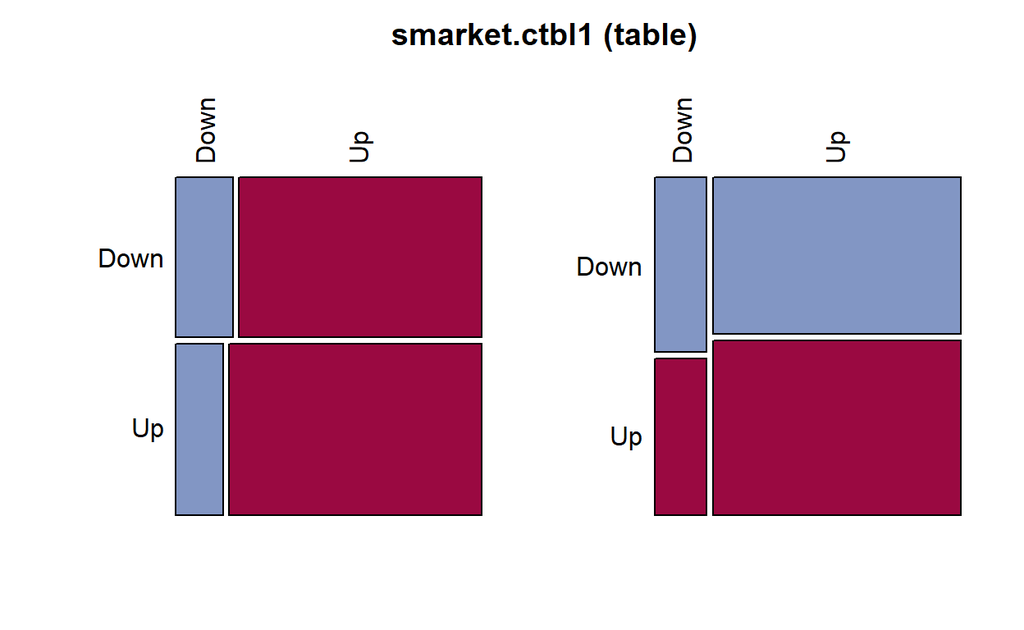

`Result!` 원래 “Down”에 속하는 602개의 개체 중 114개(114/602=18.9%)는 제대로 분류되었으나 488개(488/602=81.1%)는 잘못 분류되었다. 또한, 원래 “Up”에 속하는 648개의 개체 중 546개(546/648=84.3%)는 제대로 분류되었으나 102개(102/648=15.7%)는 잘못 분류되었다. 유도된 선형판별함수에 대한 오류율은 (488+102)/1250=47.2%이며, 정확도는 (114+546)/1250=52.8%이다.

## **5. 이차판별분석(QDA)**

```r
# 이차판별분석
pacman::p_load("MASS")

smarket.qda <- qda(Direction ~ Lag1 + Lag2,         # formula : 반응변수(클래스) ~ 예측변수
                   data = smarket)
smarket.qda
```

```
Call:
qda(Direction ~ Lag1 + Lag2, data = smarket)

Prior probabilities of groups:
  Down     Up
0.4816 0.5184

Group means:
            Lag1        Lag2
Down  0.05068605  0.03229734
Up   -0.03969136 -0.02244444
```

`Caution!` 이차판별분석에서는 판별계수벡터를 출력하지 않는다.

```r
# 새로운 개체에 대한 클래스 예측
pred2.smarket <- predict(smarket.qda,               # 함수 qda로부터 출력된 객체
                         smarket)                   # 새로운 데이터
cbind(smarket, pred2.smarket$posterior, pred2.smarket$class)
```

```
     Year   Lag1   Lag2   Lag3   Lag4   Lag5  Volume  Today Direction
1    2001  0.381 -0.192 -2.624 -1.055  5.010 1.19130  0.959        Up
2    2001  0.959  0.381 -0.192 -2.624 -1.055 1.29650  1.032        Up
3    2001  1.032  0.959  0.381 -0.192 -2.624 1.41120 -0.623      Down
4    2001 -0.623  1.032  0.959  0.381 -0.192 1.27600  0.614        Up
5    2001  0.614 -0.623  1.032  0.959  0.381 1.20570  0.213        Up
6    2001  0.213  0.614 -0.623  1.032  0.959 1.34910  1.392        Up
7    2001  1.392  0.213  0.614 -0.623  1.032 1.44500 -0.403      Down
8    2001 -0.403  1.392  0.213  0.614 -0.623 1.40780  0.027        Up
9    2001  0.027 -0.403  1.392  0.213  0.614 1.16400  1.303        Up
10   2001  1.303  0.027 -0.403  1.392  0.213 1.23260  0.287        Up
11   2001  0.287  1.303  0.027 -0.403  1.392 1.30900 -0.498      Down
12   2001 -0.498  0.287  1.303  0.027 -0.403 1.25800 -0.189      Down
13   2001 -0.189 -0.498  0.287  1.303  0.027 1.09800  0.680        Up
14   2001  0.680 -0.189 -0.498  0.287  1.303 1.05310  0.701        Up
```

[output cut: 2487 more lines]

`Caution!` 이차판별분석에서 함수 `predict()`는 예측 클래스와 각 클래스에 대한 사후확률 예측값만 출력한다.

```r
# 오분류표
pacman::p_load("DescTools")

# 도수분포표
smarket.ctbl2 <- table(smarket$Direction,           # 실제 클래스
                       pred2.smarket$class)         # 예측 클래스
smarket.ctbl2
```

```
       Down  Up
  Down  109 493
  Up     94 554
```

```r
Desc(smarket.ctbl2,                                 # 도수분포표
     digits = 4)
```

```
--------------------------------------------------------------------
smarket.ctbl2 (table)

Summary:
n: 1'250, rows: 2, columns: 2

Pearson's Chi-squared test (cont. adj):
  X-squared = 2.7148, df = 1, p-value = 0.09942
Fisher's exact test p-value = 0.09145
McNemar's chi-squared = 269.85, df = 1, p-value < 2.2e-16

                    estimate lwr.ci upr.ci'

odds ratio             1.303  0.964  1.761
rel. risk (col1)       1.248  0.970  1.607
rel. risk (col2)       0.958  0.912  1.006


Contingency Coeff.     0.049
Cramer's V             0.049
Kendall Tau-b          0.049


                  Down        Up       Sum

Down   freq        109       493       602
       perc    8.7200%  39.4400%  48.1600%
       p.row  18.1063%  81.8937%         .
       p.col  53.6946%  47.0869%         .

Up     freq         94       554       648
       perc    7.5200%  44.3200%  51.8400%
       p.row  14.5062%  85.4938%         .
       p.col  46.3054%  52.9131%         .

Sum    freq        203     1'047     1'250
       perc   16.2400%  83.7600% 100.0000%
       p.row         .         .         .
       p.col         .         .         .


----------
' 95% conf. level
```

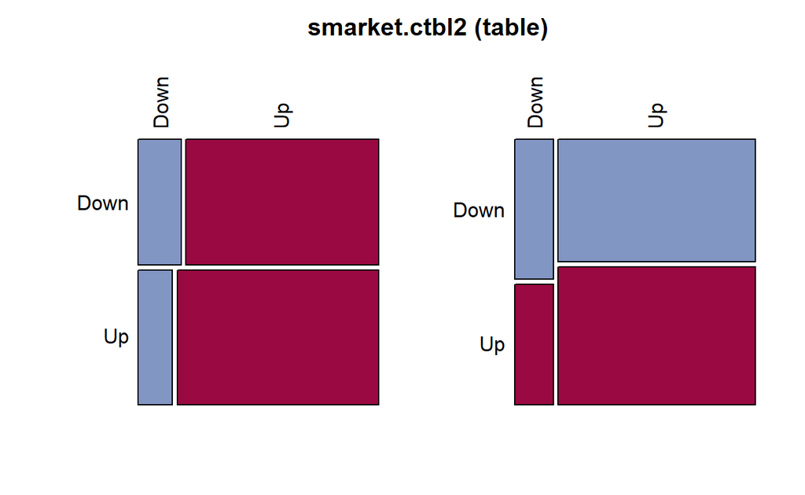

`Result!` 원래 “Down”에 속하는 602개의 개체 중 109개(109/602=18.1%)는 제대로 분류되었으나 493개(493/602=81.9%)는 잘못 분류되었다. 또한, 원래 “Up”에 속하는 648개의 개체 중 554개(554/648=85.5%)는 제대로 분류되었으나 94개(94/648=14.5%)는 잘못 분류되었다. 유도된 이차판별함수에 대한 오류율은 (493+94)/1250=47%이며, 정확도는 (109+554)/1250=53%이다.

`Caution!` Package `"klaR"`에서 제공하는 함수 `partimat()`을 통해 판별분석의 분류 영역을 각 예측변수의 쌍에 대하여 표현할 수 있다.

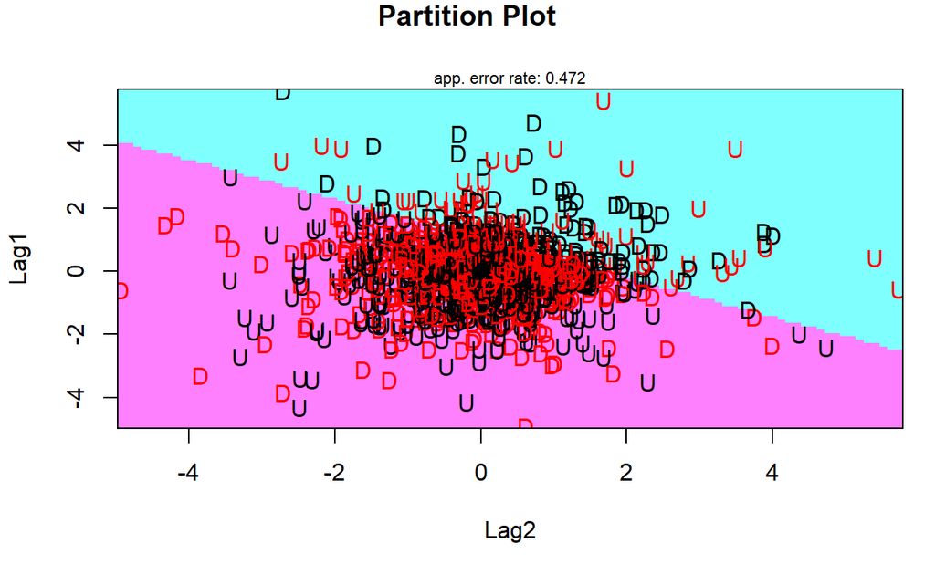

```r
# 그래프적 표현
pacman::p_load("klaR")

smarket$Direction <- as.factor(smarket$Direction)

# 선형판별함수
partimat(Direction ~ Lag1 + Lag2,
         data = smarket,
         method = "lda")
```

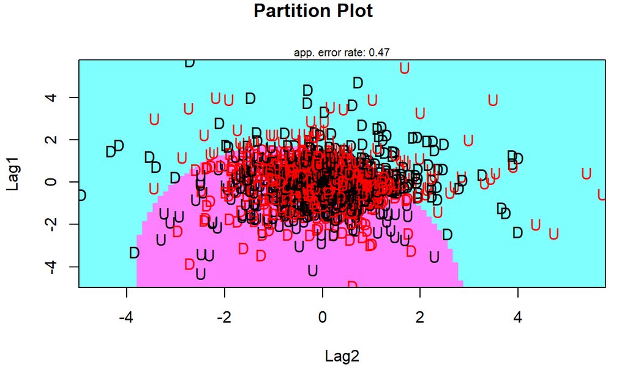

```r
# 이차판별함수
partimat(Direction ~ Lag1 + Lag2,
         data = smarket,
         method = "qda")
```

## **6. 오분류율 계산**

```r
# 1. 재대입에 의한 오분류율 계산
pacman::p_load("MASS")

smarket.lda <- lda(Direction ~ Lag1 + Lag2,         # formula : 반응변수(클래스) ~ 예측변수
                   # prior = c(1/2, 1/2),           # 사전확률
                   data = smarket)

## 예측
pred <- predict(smarket.lda,                        # 함수 lda로부터 출력된 객체
                smarket)                            # 판별함수를 유도하는 데 사용했던 데이터

## 오분류율 계산
## 함수 table()
ctbl <- table(smarket$Direction,                    # 실제 클래스
              pred$class)                           # 예측 클래스
ctbl
```

```
       Down  Up
  Down  114 488
  Up    102 546
```

```r
## 함수 Desc()
pacman::p_load("DescTools")

Desc(ctbl,                                          # 도수분포표
     digits = 4)
```

```
--------------------------------------------------------------------
ctbl (table)

Summary:
n: 1'250, rows: 2, columns: 2

Pearson's Chi-squared test (cont. adj):
  X-squared = 2.0123, df = 1, p-value = 0.156
Fisher's exact test p-value = 0.1548
McNemar's chi-squared = 251.23, df = 1, p-value < 2.2e-16

                    estimate lwr.ci upr.ci'

odds ratio             1.250  0.932  1.677
rel. risk (col1)       1.203  0.944  1.534
rel. risk (col2)       0.962  0.914  1.012


Contingency Coeff.     0.042
Cramer's V             0.042
Kendall Tau-b          0.042


                  Down        Up       Sum

Down   freq        114       488       602
       perc    9.1200%  39.0400%  48.1600%
       p.row  18.9369%  81.0631%         .
       p.col  52.7778%  47.1954%         .

Up     freq        102       546       648
       perc    8.1600%  43.6800%  51.8400%
       p.row  15.7407%  84.2593%         .
       p.col  47.2222%  52.8046%         .

Sum    freq        216     1'034     1'250
       perc   17.2800%  82.7200% 100.0000%
       p.row         .         .         .
       p.col         .         .         .


----------
' 95% conf. level
```

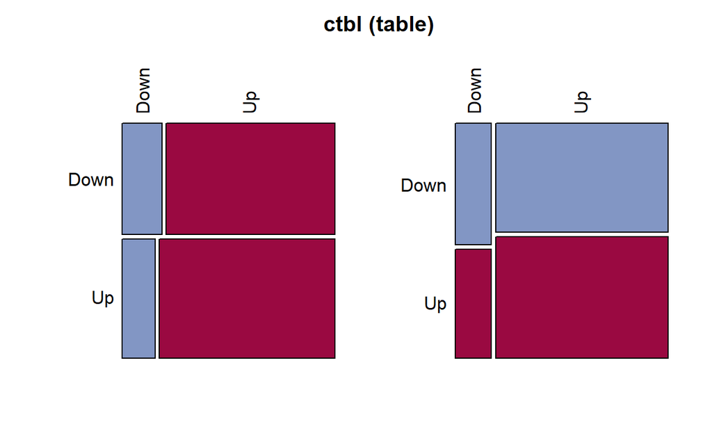

```r
## 함수 confusionMatrix()
pacman::p_load("caret")

confusionMatrix(pred$class,                          # 예측 클래스
                smarket$Direction)                   # 실제 클래스
```

```
Confusion Matrix and Statistics

          Reference
Prediction Down  Up
      Down  114 102
      Up    488 546

               Accuracy : 0.528
                 95% CI : (0.4999, 0.556)
    No Information Rate : 0.5184
    P-Value [Acc > NIR] : 0.2576

                  Kappa : 0.0327

 Mcnemar's Test P-Value : <2e-16

            Sensitivity : 0.1894
            Specificity : 0.8426
         Pos Pred Value : 0.5278
         Neg Pred Value : 0.5280
             Prevalence : 0.4816
         Detection Rate : 0.0912
   Detection Prevalence : 0.1728
      Balanced Accuracy : 0.5160

       'Positive' Class : Down
```

```r
# 2. 표본분할에 의한 오분류율 계산
## 표본 분할
pacman::p_load("caret")

set.seed(200)                                        # Seed 고정
ind <- createDataPartition(smarket$Direction,        # 반응변수 (클래스)
                           p = .7,                   # 판별함수를 유도하는 데 사용되는 데이터 비율
                           list = F)                 # 출력 결과를 List로 반환할 것인지 여부

trd <- smarket[ind,]                                 # 판별함수를 유도하는 데 사용되는 데이터
ted <- smarket[-ind,]                                # 오분류율 계산을 위해 사용되는 데이터
```

```r
pacman::p_load("MASS")

smarket.lda <- lda(Direction ~ Lag1 + Lag2,
                   data = trd)

## 예측
pred <- predict(smarket.lda,                         # 함수 lda로부터 출력된 객체
                ted)                                 # 새로운 데이터

## 오분류율 계산
## 함수 table()
ctbl <- table(ted$Direction,                         # 실제 클래스
              pred$class)                            # 예측 클래스
ctbl
```

```
       Down  Up
  Down   39 141
  Up     46 148
```

```r
## 함수 Desc()
pacman::p_load("DescTools")

Desc(ctbl,                                           # 도수분포표
     digits = 4)
```

```
--------------------------------------------------------------------
ctbl (table)

Summary:
n: 374, rows: 2, columns: 2

Pearson's Chi-squared test (cont. adj):
  X-squared = 0.12109, df = 1, p-value = 0.7279
Fisher's exact test p-value = 0.7113
McNemar's chi-squared = 47.251, df = 1, p-value = 6.244e-12

                    estimate lwr.ci upr.ci'

odds ratio             0.890  0.548  1.445
rel. risk (col1)       0.914  0.628  1.330
rel. risk (col2)       1.027  0.920  1.146


Contingency Coeff.     0.024
Cramer's V             0.024
Kendall Tau-b          -0.024


                  Down        Up       Sum

Down   freq         39       141       180
       perc   10.4278%  37.7005%  48.1283%
       p.row  21.6667%  78.3333%         .
       p.col  45.8824%  48.7889%         .

Up     freq         46       148       194
       perc   12.2995%  39.5722%  51.8717%
       p.row  23.7113%  76.2887%         .
       p.col  54.1176%  51.2111%         .

Sum    freq         85       289       374
       perc   22.7273%  77.2727% 100.0000%
       p.row         .         .         .
       p.col         .         .         .


----------
' 95% conf. level
```

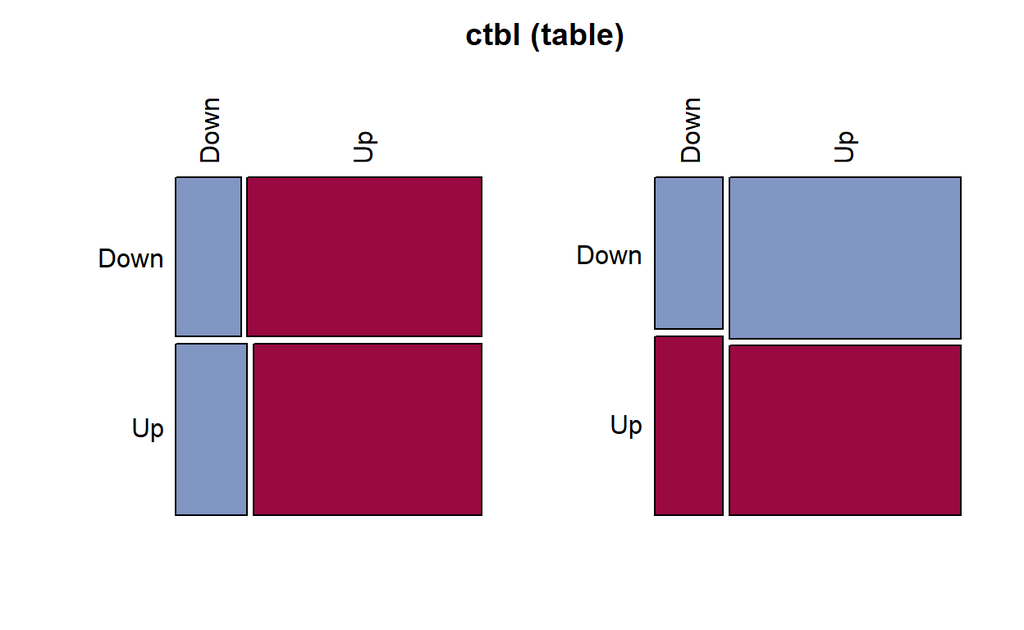

```r
## 함수 confusionMatrix()
pacman::p_load("caret")

confusionMatrix(pred$class,                          # 예측 클래스
                ted$Direction)                       # 실제 클래스
```

```
Confusion Matrix and Statistics

          Reference
Prediction Down  Up
      Down   39  46
      Up    141 148

               Accuracy : 0.5
                 95% CI : (0.4482, 0.5518)
    No Information Rate : 0.5187
    P-Value [Acc > NIR] : 0.7812

                  Kappa : -0.0208

 Mcnemar's Test P-Value : 6.244e-12

            Sensitivity : 0.2167
            Specificity : 0.7629
         Pos Pred Value : 0.4588
         Neg Pred Value : 0.5121
             Prevalence : 0.4813
         Detection Rate : 0.1043
   Detection Prevalence : 0.2273
      Balanced Accuracy : 0.4898

       'Positive' Class : Down
```

```r
# 3. 교차타당성에 의한 오분류율 계산
pacman::p_load("MASS")

smarket.lda <- lda(Direction ~ Lag1 + Lag2,
                   data = smarket,
                   CV = TRUE)
```

```r
## 오분류율 계산
## 함수 table()
ctbl <- table(smarket$Direction,                     # 실제 클래스
              smarket.lda$class)                     # 예측 클래스
ctbl
```

```
       Down  Up
  Down  109 493
  Up    109 539
```

```r
## 함수 Desc()
pacman::p_load("DescTools")

Desc(ctbl,                                           # 도수분포표
     digits = 4)
```

```
--------------------------------------------------------------------
ctbl (table)

Summary:
n: 1'250, rows: 2, columns: 2

Pearson's Chi-squared test (cont. adj):
  X-squared = 0.27437, df = 1, p-value = 0.6004
Fisher's exact test p-value = 0.5518
McNemar's chi-squared = 243.67, df = 1, p-value < 2.2e-16

                    estimate lwr.ci upr.ci'

odds ratio             1.093  0.816  1.464
rel. risk (col1)       1.076  0.846  1.370
rel. risk (col2)       0.985  0.936  1.036


Contingency Coeff.     0.017
Cramer's V             0.017
Kendall Tau-b          0.017


                  Down        Up       Sum

Down   freq        109       493       602
       perc    8.7200%  39.4400%  48.1600%
       p.row  18.1063%  81.8937%         .
       p.col  50.0000%  47.7713%         .

Up     freq        109       539       648
       perc    8.7200%  43.1200%  51.8400%
       p.row  16.8210%  83.1790%         .
       p.col  50.0000%  52.2287%         .

Sum    freq        218     1'032     1'250
       perc   17.4400%  82.5600% 100.0000%
       p.row         .         .         .
       p.col         .         .         .


----------
' 95% conf. level
```

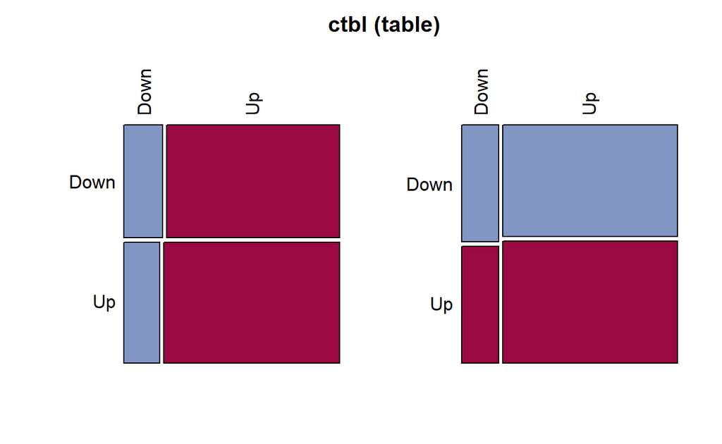

```r
## 함수 confusionMatrix()
pacman::p_load("caret")

confusionMatrix(smarket.lda$class,                   # 예측 클래스
                smarket$Direction)                   # 실제 클래스
```

```
Confusion Matrix and Statistics

          Reference
Prediction Down  Up
      Down  109 109
      Up    493 539

               Accuracy : 0.5184
                 95% CI : (0.4903, 0.5464)
    No Information Rate : 0.5184
    P-Value [Acc > NIR] : 0.5114

                  Kappa : 0.0132

 Mcnemar's Test P-Value : <2e-16

            Sensitivity : 0.1811
            Specificity : 0.8318
         Pos Pred Value : 0.5000
         Neg Pred Value : 0.5223
             Prevalence : 0.4816
         Detection Rate : 0.0872
   Detection Prevalence : 0.1744
      Balanced Accuracy : 0.5064

       'Positive' Class : Down
```